# WQX Upload QC

Inigo Peng

2022-10-24

# WQX Data QC

## Description of Data

The data we are using to go through the QC process is the cleaned WQX dataset from Alpha Lab, Bend Genetics, and Hydro Lab.

## Access Lab Data

We will first read in the wqx ready lab data. We will bind it into one data frame so we only have to perform the qc procedure once. We will use the read_csv function. We will then bind the three data frames into one large data frame called combined_lab_data.

```r
alpha_lab_wqx <- read_csv("data/alpha_lab_wqx.csv", col_types = cols(.default = "c"))

bend_wqx <- read_csv("data/bend_wqx.csv", col_types = cols(.default = "c"))

hydrolab_wqx <- read_csv("data/hydrolab_wqx.csv", col_types = cols(.default = "c"))
```

```r
combined_lab_data <- bind_rows(alpha_lab_wqx, bend_wqx, hydrolab_wqx) |> glimpse()
```

```
## Rows: 60
## Columns: 36
## $ `Project ID`                                  <chr> "CalWATCH", "CalWATCH", …
## $ `Monitoring Location ID`                      <chr> NA, NA, NA, NA, NA, NA, …
## $ `Activity ID (CHILD-subset)`                  <chr> "NA:07252022:0900:SR:WB:…
## $ `Activity ID User Supplied (PARENTs)`         <chr> NA, NA, NA, NA, NA, NA, …
## $ `Activity Type`                               <chr> "Sample-Routine", "Sampl…
## $ `Activity Media Name`                         <chr> "Water", "Water", "Water…
## $ `Activity Start Date`                         <chr> "07/25/2022", "07/25/202…
## $ `Activity Start Time`                         <chr> "09:00", "09:00", "09:00…
## $ `Activity Start Time Zone`                    <chr> "PST", "PST", "PST", "PS…
## $ `Activity Depth/Height Measure`               <chr> NA, NA, NA, NA, NA, NA, …
## $ `Activity Depth/Height Unit`                  <chr> NA, NA, NA, NA, NA, NA, …
## $ `Sample Collection Method ID`                 <chr> "BVR SWQAPP", "BVR SWQAP…
## $ `Sample Collection Method Context`            <chr> "CA_BVR", "CA_BVR", "CA_…
```

[output cut: 23 more lines]

## Data transformations

```r
combined_lab_data <- combined_lab_data |>
  mutate(`Activity Depth/Height Measure` = as.numeric(`Activity Depth/Height Measure`),
         `Result Value` = as.numeric(`Result Value`),
         `Result Detection/Quantitation Limit Measure` = as.numeric(`Result Detection/Quantitation Limit Measure`)) |> glimpse()
```

```
## Rows: 60
## Columns: 36
## $ `Project ID`                                  <chr> "CalWATCH", "CalWATCH", …
## $ `Monitoring Location ID`                      <chr> NA, NA, NA, NA, NA, NA, …
## $ `Activity ID (CHILD-subset)`                  <chr> "NA:07252022:0900:SR:WB:…
## $ `Activity ID User Supplied (PARENTs)`         <chr> NA, NA, NA, NA, NA, NA, …
## $ `Activity Type`                               <chr> "Sample-Routine", "Sampl…
## $ `Activity Media Name`                         <chr> "Water", "Water", "Water…
## $ `Activity Start Date`                         <chr> "07/25/2022", "07/25/202…
## $ `Activity Start Time`                         <chr> "09:00", "09:00", "09:00…
## $ `Activity Start Time Zone`                    <chr> "PST", "PST", "PST", "PS…
## $ `Activity Depth/Height Measure`               <dbl> NA, NA, NA, NA, NA, NA, …
## $ `Activity Depth/Height Unit`                  <chr> NA, NA, NA, NA, NA, NA, …
## $ `Sample Collection Method ID`                 <chr> "BVR SWQAPP", "BVR SWQAP…
## $ `Sample Collection Method Context`            <chr> "CA_BVR", "CA_BVR", "CA_…
```

[output cut: 23 more lines]

## Explore Numeric Variables

Now we explore these numeric values.

```r
combined_lab_data |> select_if(is.numeric) |> colnames()
```

```
## [1] "Activity Depth/Height Measure"
## [2] "Result Value"
## [3] "Result Detection/Quantitation Limit Measure"
```

### Variable: `Activity Depth/Height Measure`, `Result Value`, `Result Detection/Quantitation Limit Measure`

The summary function produces summaries of the results such as min, max. Values that are not in the normal range could be spotted.

```r
summary(combined_lab_data$`Activity Depth/Height Measure`)
```

```
##    Min. 1st Qu.  Median    Mean 3rd Qu.    Max.    NA's
##   0.195   0.195   0.342   0.342   0.489   0.489      42
```

```r
summary(combined_lab_data$`Result Value`)
```

```
##      Min.   1st Qu.    Median      Mean   3rd Qu.      Max.      NA's
##      0.00      0.53      5.95   4545.00     22.81 171298.00        19
```

```r
summary(combined_lab_data$`Result Detection/Quantitation Limit Measure`)
```

```
##    Min. 1st Qu.  Median    Mean 3rd Qu.    Max.    NA's
##   0.040   0.150   1.125  39.871 100.000 150.000      30
```

## Explore water quality variables:

```r
unique(combined_lab_data$`Characteristic Name`)
```

```
##  [1] "Total Coliforms"
##  [2] "Escherichia coli"
##  [3] "Nitrate as N"
##  [4] "Microcystin/nodularin genes mcyE/ndaF"
##  [5] "Microcystin"
##  [6] "Cylindrospermopsin"
##  [7] "Saxitoxin"
##  [8] "Temperature, water"
##  [9] "Specific conductance"
## [10] "Resistivity"
## [11] "Salinity"
## [12] "Total dissolved solids"
## [13] "Dissolved oxygen saturation"
## [14] "Dissolved oxygen (DO)"
## [15] "pH"
## [16] "Turbidity"
```

### Variable: `Result Value`

**Plotting result value per water quality variable

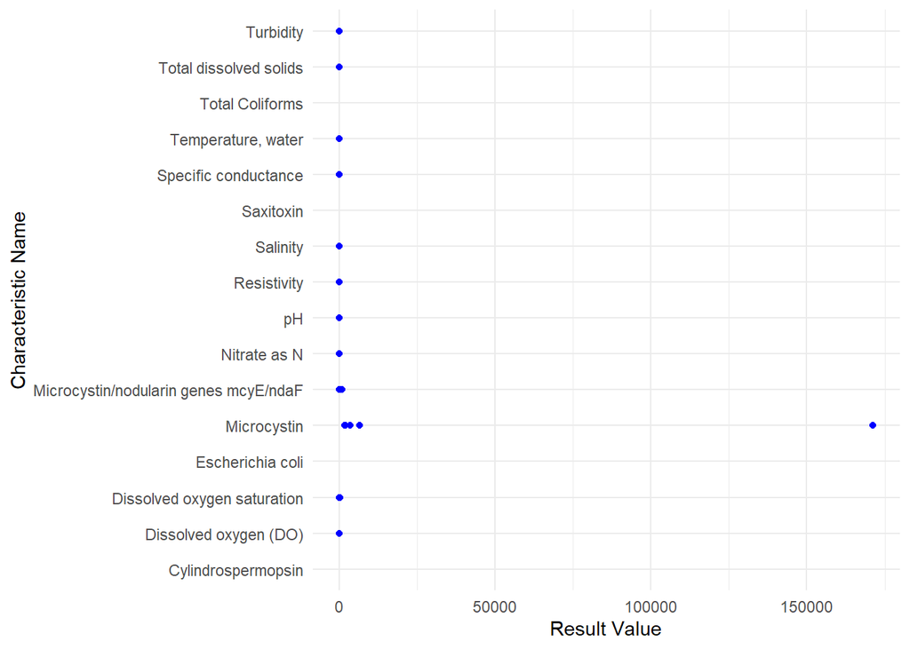

```r
combined_lab_data |>
  ggplot(aes(x = `Result Value`,  y = `Characteristic Name`)) +
  geom_point(color = "blue") +
  labs(x = "Result Value",
       y = "Characteristic Name") +
  theme_minimal()
```

We could filter our data based on each water quality variable to get a more detailed look at each variable.

### Water Quality Characteristic: Turbidity

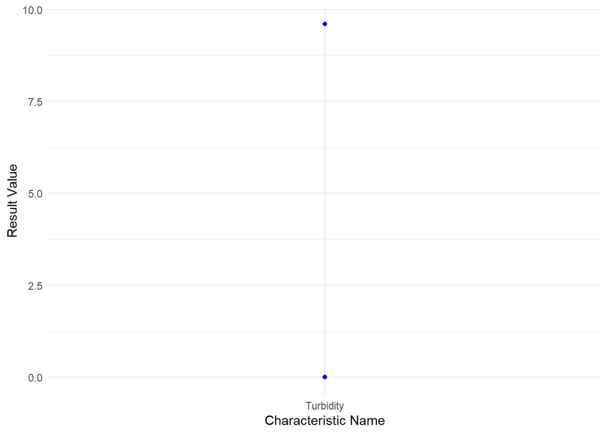

```r
combined_lab_data |>
  filter(`Characteristic Name` == "Turbidity") |>
  ggplot(aes(x = `Characteristic Name`, y = `Result Value`)) +
  geom_point(color = "blue") +
  labs(y = "Result Value",
       x = "Characteristic Name") +
  theme_minimal()
```

```r
summary(combined_lab_data |>
          filter(`Characteristic Name` == "Turbidity") |>
        select(`Result Value`))
```

```
##   Result Value
##  Min.   :0.0
##  1st Qu.:2.4
##  Median :4.8
##  Mean   :4.8
##  3rd Qu.:7.2
##  Max.   :9.6
```

### Water Quality Characteristic: Total Dissolved Solids

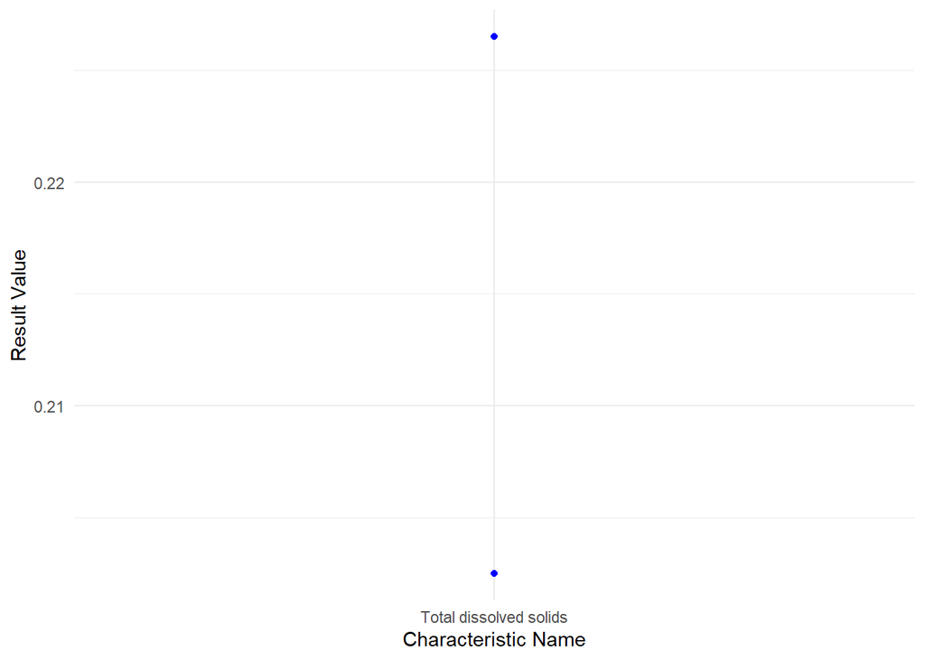

```r
combined_lab_data |>
  filter(`Characteristic Name` == "Total dissolved solids") |>
  ggplot(aes(x = `Characteristic Name`, y = `Result Value`)) +
  geom_point(color = "blue") +
  labs(y = "Result Value",
       x = "Characteristic Name") +
  theme_minimal()
```

```r
summary(combined_lab_data |>
          filter(`Characteristic Name` == "Total dissolved solids") |>
        select(`Result Value`))
```

```
##   Result Value
##  Min.   :0.2025
##  1st Qu.:0.2085
##  Median :0.2145
##  Mean   :0.2145
##  3rd Qu.:0.2205
##  Max.   :0.2265
```

### Water Quality Characteristic: Nitrate as N

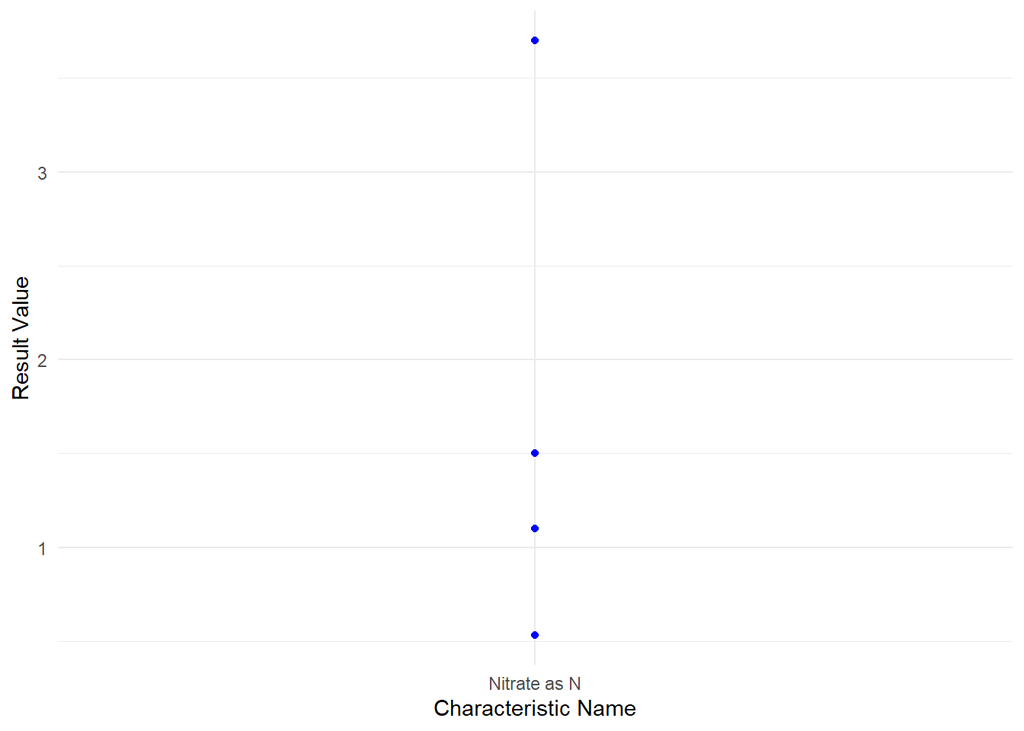

```r
combined_lab_data |>
  filter(`Characteristic Name` == "Nitrate as N") |>
  ggplot(aes(x = `Characteristic Name`, y = `Result Value`)) +
  geom_point(color = "blue") +
  labs(y = "Result Value",
       x = "Characteristic Name") +
  theme_minimal()
```

```r
summary(combined_lab_data |>
          filter(`Characteristic Name` == "Nitrate as N") |>
        select(`Result Value`))
```

```
##   Result Value
##  Min.   :0.5300
##  1st Qu.:0.9575
##  Median :1.3000
##  Mean   :1.7075
##  3rd Qu.:2.0500
##  Max.   :3.7000
##  NA's   :2
```

### Water Quality Characteristic: Microcystin/nodularin genes mcyE/ndaF

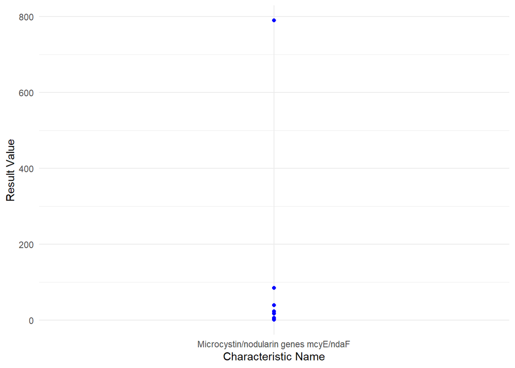

```r
combined_lab_data |>
  filter(`Characteristic Name` == "Microcystin/nodularin genes mcyE/ndaF") |>
  ggplot(aes(x = `Characteristic Name`, y = `Result Value`)) +
  geom_point(color = "blue") +
  labs(y = "Result Value",
       x = "Characteristic Name") +
  theme_minimal()
```

```r
summary(combined_lab_data |>
          filter(`Characteristic Name` == "Microcystin/nodularin genes mcyE/ndaF") |>
        select(`Result Value`))
```

```
##   Result Value
##  Min.   :  0.290
##  1st Qu.:  2.255
##  Median :  5.260
##  Mean   : 70.782
##  3rd Qu.: 21.512
##  Max.   :790.000
```

### Water Quality Characteristic: Microcystin

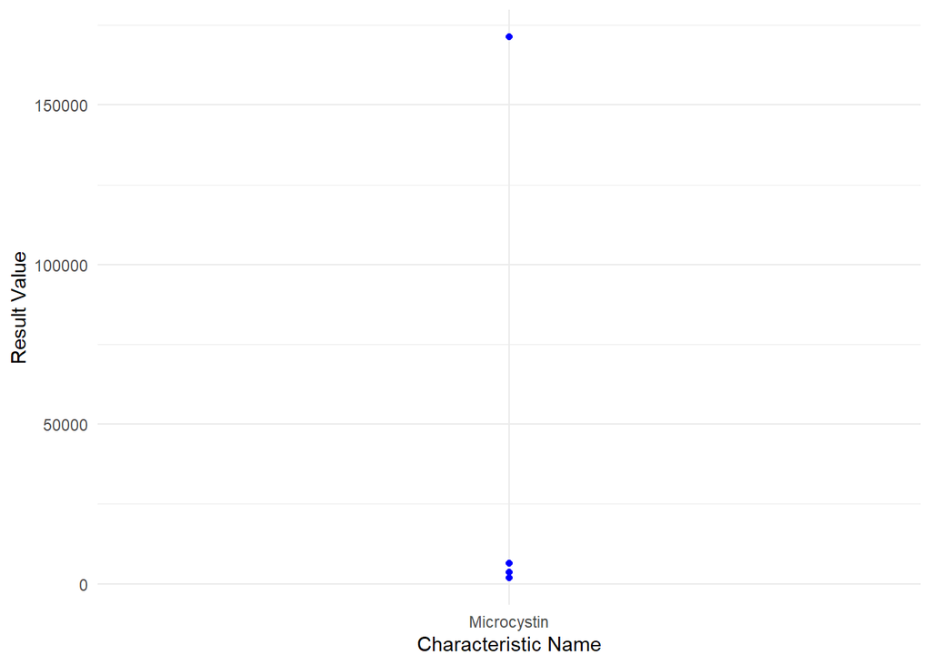

```r
combined_lab_data |>
  filter(`Characteristic Name` == "Microcystin") |>
  ggplot(aes(x = `Characteristic Name`, y = `Result Value`)) +
  geom_point(color = "blue") +
  labs(y = "Result Value",
       x = "Characteristic Name") +
  theme_minimal()
```

```r
summary(combined_lab_data |>
          filter(`Characteristic Name` == "Microcystin") |>
        select(`Result Value`))
```

```
##   Result Value
##  Min.   :  1813
##  1st Qu.:  1903
##  Median :  3586
##  Mean   : 37015
##  3rd Qu.:  6475
##  Max.   :171298
##  NA's   :3
```

### Water Quality Characteristic: Temperature, water

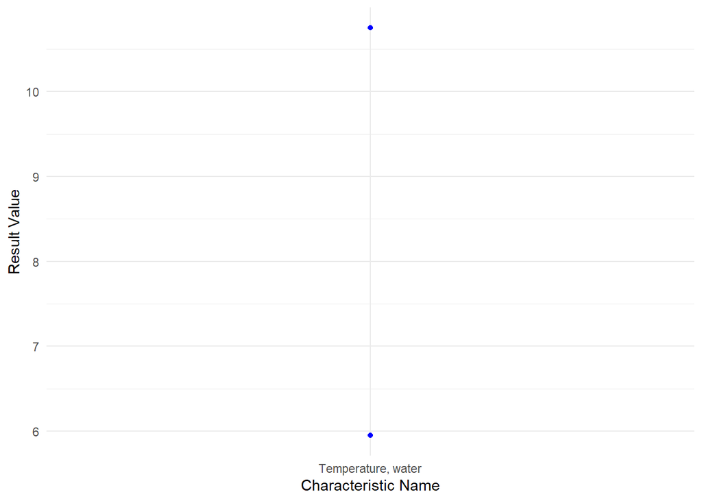

```r
combined_lab_data |>
  filter(`Characteristic Name` == "Temperature, water") |>
  ggplot(aes(x = `Characteristic Name`, y = `Result Value`)) +
  geom_point(color = "blue") +
  labs(y = "Result Value",
       x = "Characteristic Name") +
  theme_minimal()
```

```r
summary(combined_lab_data |>
          filter(`Characteristic Name` == "Temperature, water") |>
        select(`Result Value`))
```

```
##   Result Value
##  Min.   : 5.95
##  1st Qu.: 7.15
##  Median : 8.35
##  Mean   : 8.35
##  3rd Qu.: 9.55
##  Max.   :10.75
```

### Water Quality Characteristic: Specific conductance

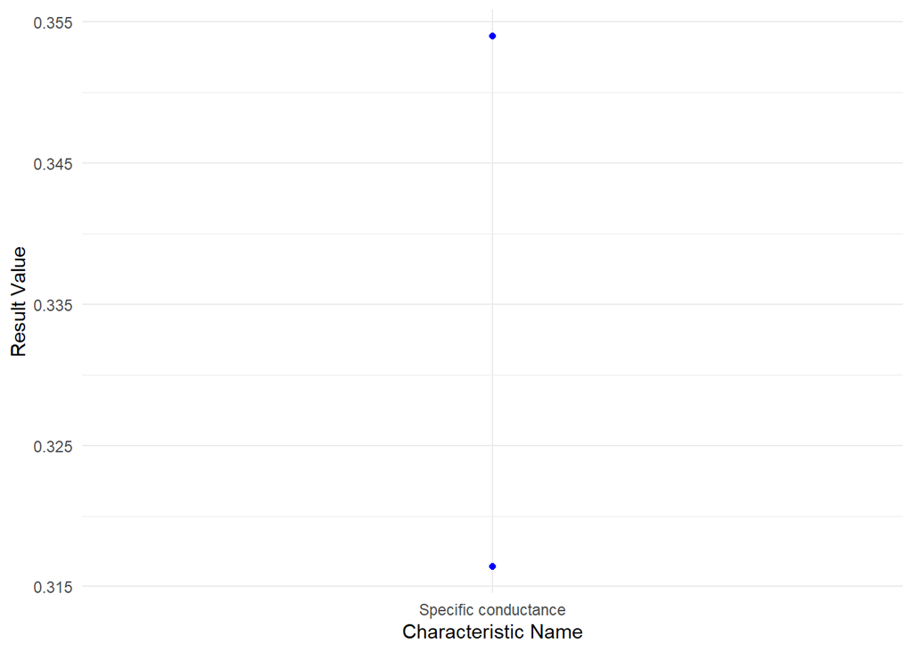

```r
combined_lab_data |>
  filter(`Characteristic Name` == "Specific conductance") |>
  ggplot(aes(x = `Characteristic Name`, y = `Result Value`)) +
  geom_point(color = "blue") +
  labs(y = "Result Value",
       x = "Characteristic Name") +
  theme_minimal()
```

```r
summary(combined_lab_data |>
          filter(`Characteristic Name` == "Specific conductance") |>
        select(`Result Value`))
```

```
##   Result Value
##  Min.   :0.3164
##  1st Qu.:0.3258
##  Median :0.3352
##  Mean   :0.3352
##  3rd Qu.:0.3446
##  Max.   :0.3540
```

### Water Quality Characteristic: Resistivity

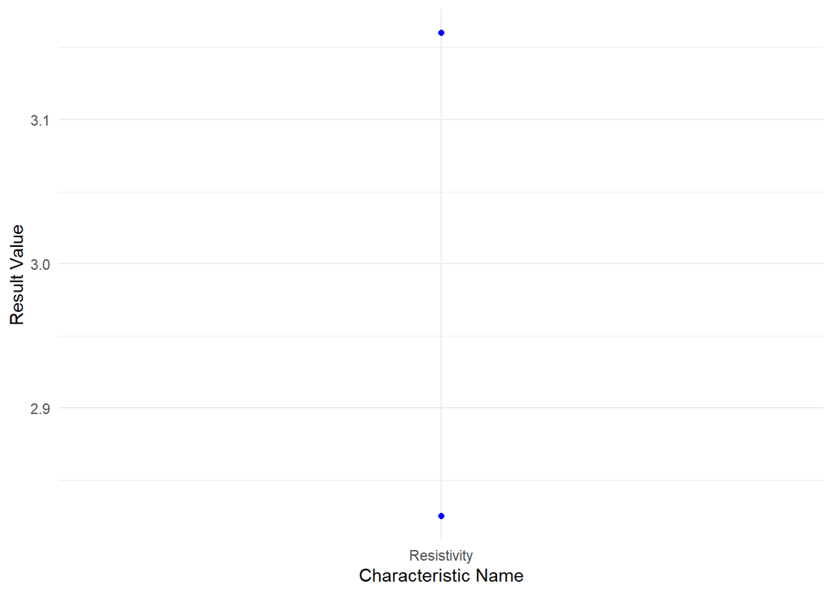

```r
combined_lab_data |>
  filter(`Characteristic Name` == "Resistivity") |>
  ggplot(aes(x = `Characteristic Name`, y = `Result Value`)) +
  geom_point(color = "blue") +
  labs(y = "Result Value",
       x = "Characteristic Name") +
  theme_minimal()
```

```r
summary(combined_lab_data |>
          filter(`Characteristic Name` == "Resistivity") |>
        select(`Result Value`))
```

```
##   Result Value
##  Min.   :2.825
##  1st Qu.:2.909
##  Median :2.993
##  Mean   :2.993
##  3rd Qu.:3.076
##  Max.   :3.160
```

### Water Quality Characteristic: Salinity

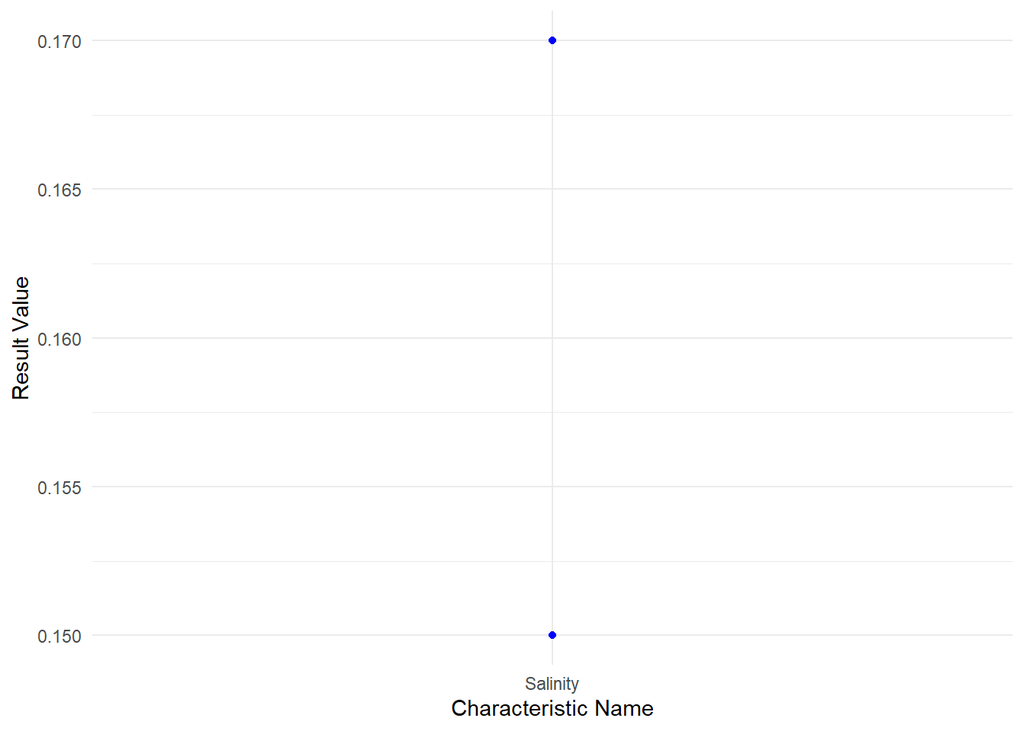

```r
combined_lab_data |>
  filter(`Characteristic Name` == "Salinity") |>
  ggplot(aes(x = `Characteristic Name`, y = `Result Value`)) +
  geom_point(color = "blue") +
  labs(y = "Result Value",
       x = "Characteristic Name") +
  theme_minimal()
```

```r
summary(combined_lab_data |>
          filter(`Characteristic Name` == "Salinity") |>
        select(`Result Value`))
```

```
##   Result Value
##  Min.   :0.150
##  1st Qu.:0.155
##  Median :0.160
##  Mean   :0.160
##  3rd Qu.:0.165
##  Max.   :0.170
```

### Water Quality Characteristic: Dissolved oxygen saturation

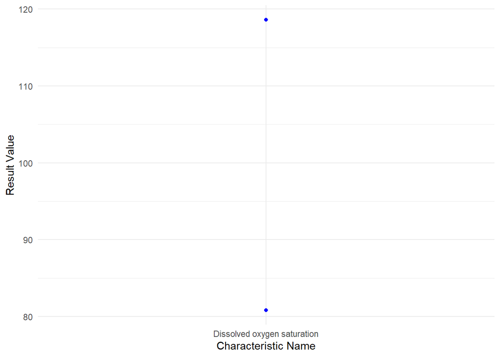

```r
combined_lab_data |>
  filter(`Characteristic Name` == "Dissolved oxygen saturation") |>
  ggplot(aes(x = `Characteristic Name`, y = `Result Value`)) +
  geom_point(color = "blue") +
  labs(y = "Result Value",
       x = "Characteristic Name") +
  theme_minimal()
```

```r
summary(combined_lab_data |>
          filter(`Characteristic Name` == "Dissolved oxygen saturation") |>
        select(`Result Value`))
```

```
##   Result Value
##  Min.   : 80.80
##  1st Qu.: 90.25
##  Median : 99.70
##  Mean   : 99.70
##  3rd Qu.:109.15
##  Max.   :118.60
```

### Water Quality Characteristic: Dissolved oxygen (DO)

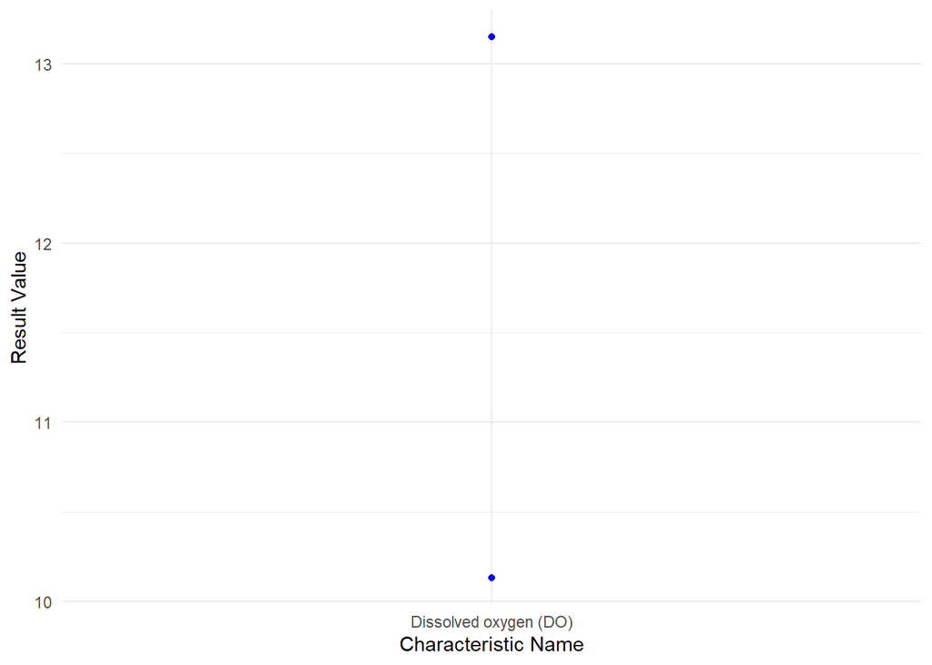

```r
combined_lab_data |>
  filter(`Characteristic Name` == "Dissolved oxygen (DO)") |>
  ggplot(aes(x = `Characteristic Name`, y = `Result Value`)) +
  geom_point(color = "blue") +
  labs(y = "Result Value",
       x = "Characteristic Name") +
  theme_minimal()
```

```r
summary(combined_lab_data |>
          filter(`Characteristic Name` == "Dissolved oxygen (DO)") |>
        select(`Result Value`))
```

```
##   Result Value
##  Min.   :10.13
##  1st Qu.:10.88
##  Median :11.64
##  Mean   :11.64
##  3rd Qu.:12.39
##  Max.   :13.15
```

### Water Quality Characteristic: pH

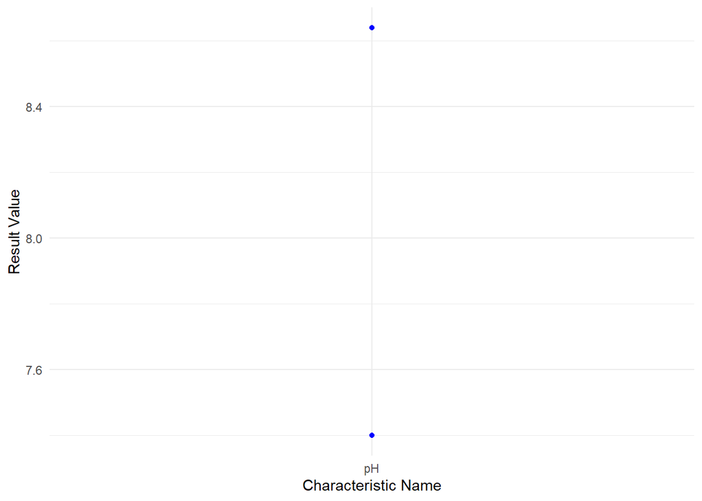

```r
combined_lab_data |>
  filter(`Characteristic Name` == "pH") |>
  ggplot(aes(x = `Characteristic Name`, y = `Result Value`)) +
  geom_point(color = "blue") +
  labs(y = "Result Value",
       x = "Characteristic Name") +
  theme_minimal()
```

```r
summary(combined_lab_data |>
          filter(`Characteristic Name` == "pH") |>
        select(`Result Value`))
```

```
##   Result Value
##  Min.   :7.40
##  1st Qu.:7.71
##  Median :8.02
##  Mean   :8.02
##  3rd Qu.:8.33
##  Max.   :8.64
```